# Customer Segmentation using K-Means Clustering

Chayut Phukson

2022-10-14

# Import Library

```r
library(tidyverse)
```

```r
library(plotrix) # create pie chart
library(skmeans)
library(gridExtra)
```

# Import Dataset

ref: “https://www.kaggle.com/datasets/vjchoudhary7/customer-segmentation-tutorial-in-python?select=Mall_Customers.csv”

```r
Mall_Customers <- read.csv("Mall_Customers.csv", stringsAsFactors = T)
```

```r
Mall_Customers
```

```
##     CustomerID Gender Age Annual.Income..k.. Spending.Score..1.100.
## 1            1   Male  19                 15                     39
## 2            2   Male  21                 15                     81
## 3            3 Female  20                 16                      6
## 4            4 Female  23                 16                     77
## 5            5 Female  31                 17                     40
## 6            6 Female  22                 17                     76
## 7            7 Female  35                 18                      6
## 8            8 Female  23                 18                     94
## 9            9   Male  64                 19                      3
## 10          10 Female  30                 19                     72
## 11          11   Male  67                 19                     14
## 12          12 Female  35                 19                     99
## 13          13 Female  58                 20                     15
## 14          14 Female  24                 20                     77
```

[output cut: 186 more lines]

# Review Dataset

```r
head(Mall_Customers)
```

```
##   CustomerID Gender Age Annual.Income..k.. Spending.Score..1.100.
## 1          1   Male  19                 15                     39
## 2          2   Male  21                 15                     81
## 3          3 Female  20                 16                      6
## 4          4 Female  23                 16                     77
## 5          5 Female  31                 17                     40
## 6          6 Female  22                 17                     76
```

```r
names(Mall_Customers)
```

```
## [1] "CustomerID"             "Gender"                 "Age"
## [4] "Annual.Income..k.."     "Spending.Score..1.100."
```

```r
str(Mall_Customers)
```

```
## 'data.frame':    200 obs. of  5 variables:
##  $ CustomerID            : int  1 2 3 4 5 6 7 8 9 10 ...
##  $ Gender                : Factor w/ 2 levels "Female","Male": 2 2 1 1 1 1 1 1 2 1 ...
##  $ Age                   : int  19 21 20 23 31 22 35 23 64 30 ...
##  $ Annual.Income..k..    : int  15 15 16 16 17 17 18 18 19 19 ...
##  $ Spending.Score..1.100.: int  39 81 6 77 40 76 6 94 3 72 ...
```

```r
summary(Mall_Customers)
```

```
##    CustomerID        Gender         Age        Annual.Income..k..
##  Min.   :  1.00   Female:112   Min.   :18.00   Min.   : 15.00
##  1st Qu.: 50.75   Male  : 88   1st Qu.:28.75   1st Qu.: 41.50
##  Median :100.50                Median :36.00   Median : 61.50
##  Mean   :100.50                Mean   :38.85   Mean   : 60.56
##  3rd Qu.:150.25                3rd Qu.:49.00   3rd Qu.: 78.00
##  Max.   :200.00                Max.   :70.00   Max.   :137.00
##  Spending.Score..1.100.
##  Min.   : 1.00
##  1st Qu.:34.75
##  Median :50.00
##  Mean   :50.20
##  3rd Qu.:73.00
##  Max.   :99.00
```

```r
# check NA
sum(is.na(Mall_Customers))
```

```
## [1] 0
```

# Customer Gender Visualization

# Using BarPlot to display Gender Comparision

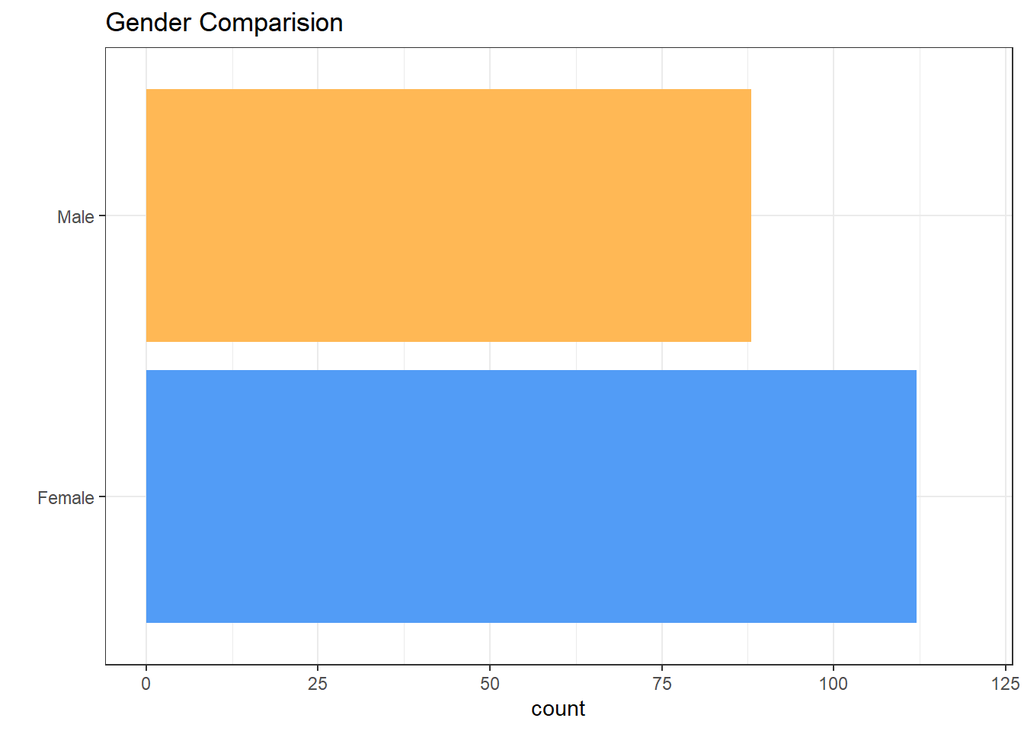

```r
Mall_Customers %>%
  ggplot(aes(Gender)) +
  geom_bar(fill = c("#529cf6", "#ffb855")) +
  ylim(0,120) +
  labs(title = "Gender Comparision") +
  theme_bw() +
  coord_flip() +
  xlab("")
```

# Pie Chart Depicting Ratio of Female and Male

```r
Gender_Table <- table(Mall_Customers$Gender)
Gender_Table
```

```
##
## Female   Male
##    112     88
```

```r
Percent_Gender <- (table(Mall_Customers$Gender)/sum(table(Mall_Customers))) * 100
Percent_Gender
```

```
##
## Female   Male
##     56     44
```

```r
Gender_labels <- paste(c("Female","Male"), " ", Percent_Gender, "%", sep = " ")
```

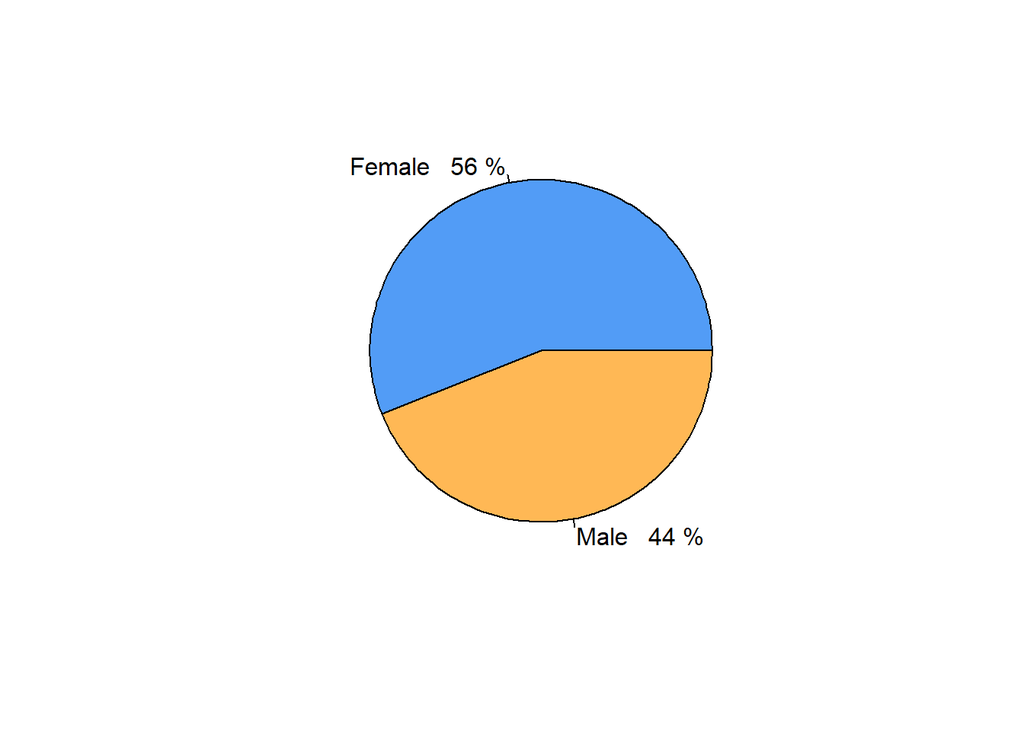

```r
# Create pie chart
pie(x = Gender_Table, labels = Gender_labels, col = c("#529cf6", "#ffb855"))
```

# Visualization of Age Distribution

```r
table(Mall_Customers$Age)
```

```
##
## 18 19 20 21 22 23 24 25 26 27 28 29 30 31 32 33 34 35 36 37 38 39 40 41 42 43
##  4  8  5  5  3  6  4  3  2  6  4  5  7  8 11  3  5  9  6  3  6  3  6  2  2  3
## 44 45 46 47 48 49 50 51 52 53 54 55 56 57 58 59 60 63 64 65 66 67 68 69 70
##  2  3  3  6  5  7  5  2  2  2  4  1  1  2  2  4  3  2  1  2  2  4  3  1  2
```

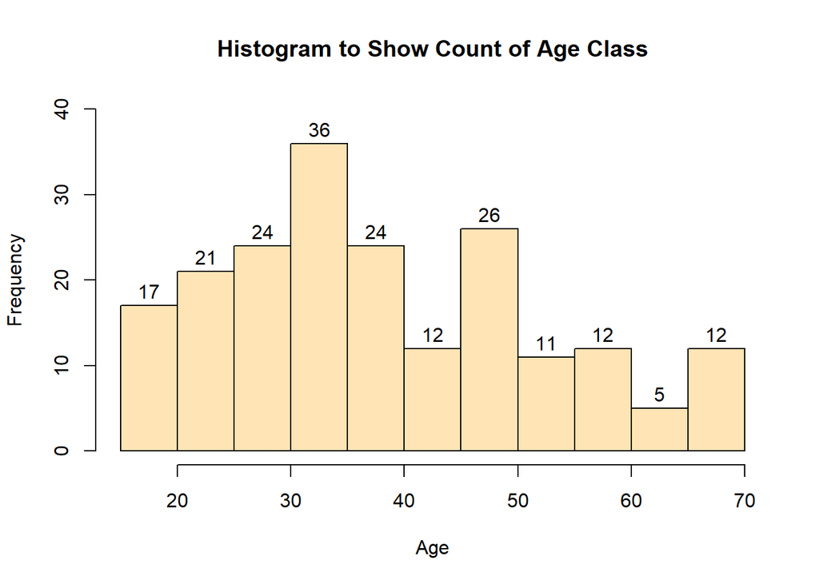

```r
hist(Mall_Customers$Age,
    col = "#FFE4B5",
    main = "Histogram to Show Count of Age Class",
    ylim = c(0,40),
    xlab = "Age",
    ylab = "Frequency",
    labels = TRUE)
```

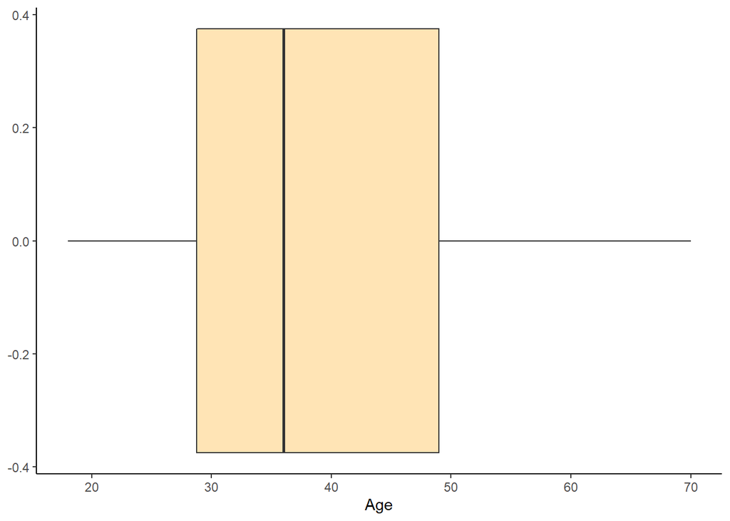

```r
Mall_Customers %>%
  ggplot(aes(x = Age)) +
  geom_boxplot(fill = "#FFE4B5") +
  theme_classic()
```

# Analysis of the Annual Income of the Customers

# Descriptive Analysis

```r
table(Mall_Customers$Annual.Income..k..)
```

```
##
##  15  16  17  18  19  20  21  23  24  25  28  29  30  33  34  37  38  39  40  42
##   2   2   2   2   4   4   2   2   2   2   4   2   2   4   2   2   2   4   4   2
##  43  44  46  47  48  49  50  54  57  58  59  60  61  62  63  64  65  67  69  70
##   4   2   4   2   6   2   2  12   2   2   2   6   2   6   6   2   4   4   2   2
##  71  72  73  74  75  76  77  78  79  81  85  86  87  88  93  97  98  99 101 103
##   6   2   4   2   2   2   4  12   2   2   2   2   6   4   2   2   2   2   2   4
## 113 120 126 137
##   2   2   2   2
```

```r
summary(Mall_Customers$Annual.Income..k..)
```

```
##    Min. 1st Qu.  Median    Mean 3rd Qu.    Max.
##   15.00   41.50   61.50   60.56   78.00  137.00
```

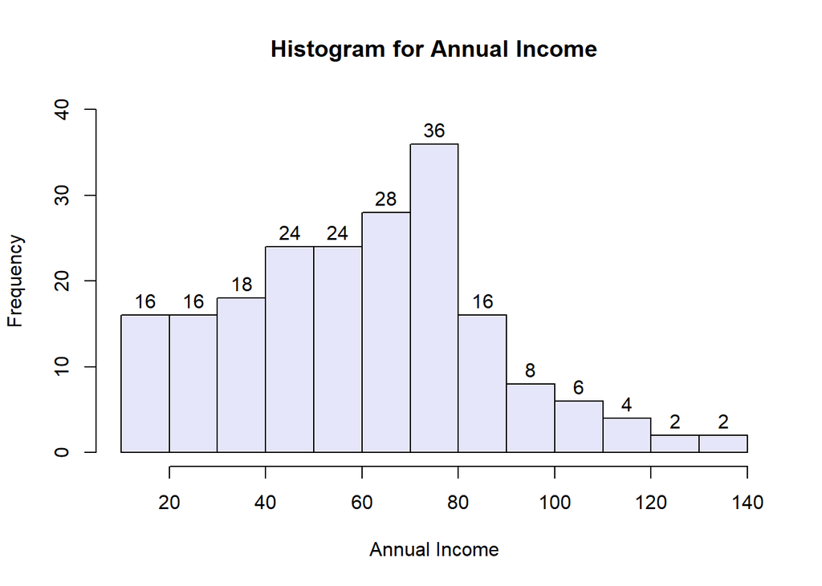

```r
hist(Mall_Customers$Annual.Income..k..,
    col = "#E6E6FA",
    main = "Histogram for Annual Income",
    ylim = c(0, 40),
    xlab = "Annual Income",
    ylab = "Frequency",
    labels = TRUE)
```

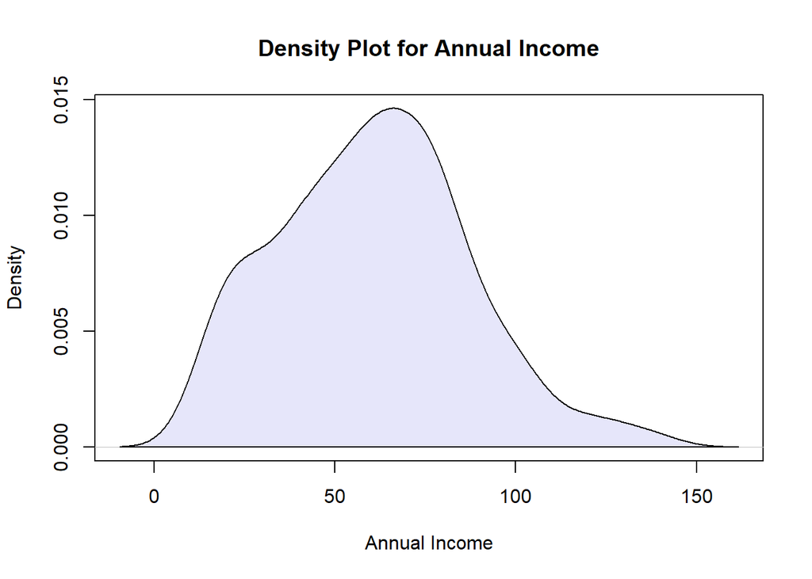

```r
plot(density(Mall_Customers$Annual.Income..k..),
    main = "Density Plot for Annual Income",
    xlab = "Annual Income",
    ylab = "Density")
polygon(density(Mall_Customers$Annual.Income..k..), col = "#E6E6FA")
```

# Analyzing Spending Score of the Customers

```r
table(Mall_Customers$Spending.Score..1.100.)
```

```
##
##  1  3  4  5  6  7  8  9 10 11 12 13 14 15 16 17 18 20 22 23 24 26 27 28 29 31
##  2  1  2  4  2  1  1  1  2  1  1  3  4  3  2  3  1  2  1  1  1  2  1  2  2  1
## 32 34 35 36 39 40 41 42 43 44 45 46 47 48 49 50 51 52 53 54 55 56 57 58 59 60
##  2  1  5  2  2  4  4  8  3  1  1  6  4  5  3  5  3  5  1  3  7  4  2  2  5  3
## 61 63 65 66 68 69 71 72 73 74 75 76 77 78 79 81 82 83 85 86 87 88 89 90 91 92
##  2  1  1  1  1  2  1  2  6  2  5  2  3  1  2  2  1  2  1  2  2  3  1  2  2  3
## 93 94 95 97 98 99
##  2  1  2  2  1  1
```

```r
summary(Mall_Customers$Spending.Score..1.100.)
```

```
##    Min. 1st Qu.  Median    Mean 3rd Qu.    Max.
##    1.00   34.75   50.00   50.20   73.00   99.00
```

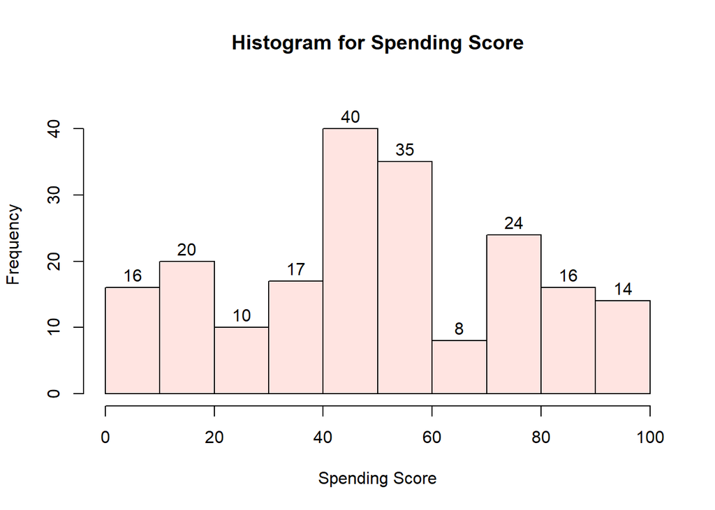

```r
hist(Mall_Customers$Spending.Score..1.100.,
    main = "Histogram for Spending Score",
    ylim = c(0,45),
    xlab = "Spending Score",
    ylab = "Frequency",
    col = "#FFE4E1",
    labels = TRUE)
```

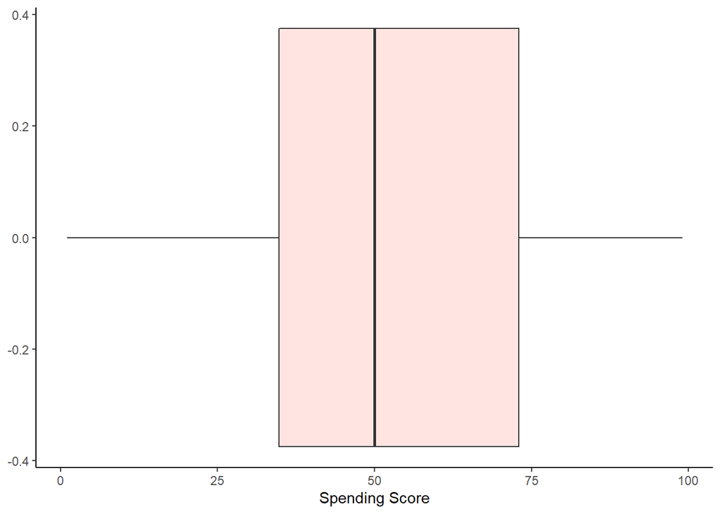

```r
Mall_Customers %>%
  ggplot(aes(x = Spending.Score..1.100.)) +
  geom_boxplot(fill = "#FFE4E1") +
  xlab("Spending Score") +
  theme_classic()
```

# Elbow Method

Customer Segmentation with Psychographics (social class, lifestyle, personality traits) and Behavioral data (spending and consumption habits, product/service usage)

# 1. Customer Segmentation with Annual Income and Speding Score

We customer Segmentation with Annual Income of the customee and the Speding Score.

```r
# select variables Annual Income and the Speding Score
k_newdata <- Mall_Customers[ , c(4:5)]
```

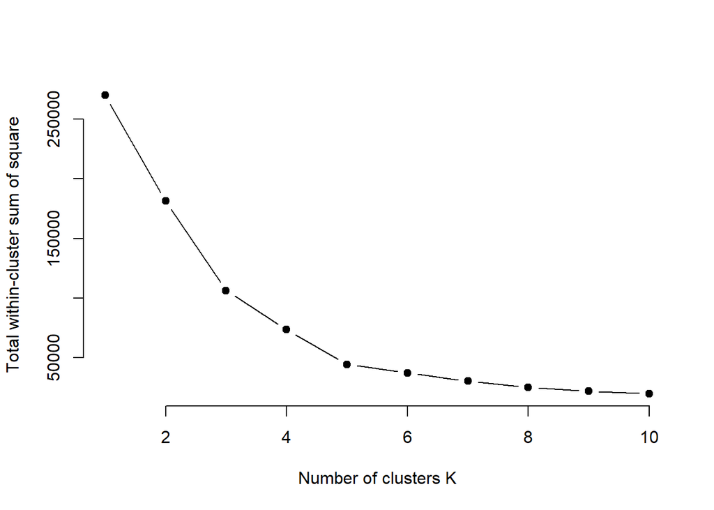

```r
library(purrr)
set.seed(111)
# function to calculate total within-cluster sum of square (WCSS)
wcss <- function(k) {
  kmeans(k_newdata,
         k,
         iter.max = 100,
         nstart = 100,
         algorithm = "Lloyd" )$tot.withinss
}
# compute and plot wcss for k = 1 to k = 10
k_values <- 1:10

wcss_values <- map_dbl(k_values, wcss)

plot(k_values, wcss_values,
     type = "b",
     pch = 19,
     frame = FALSE,
     xlab = "Number of clusters K",
     ylab = "Total within-cluster sum of square")
```

# Compute k-means with k = 5

```r
set.seed(111)
customerClusters <- kmeans(k_newdata, 5)
customerClusters
```

```
## K-means clustering with 5 clusters of sizes 81, 23, 39, 22, 35
##
## Cluster means:
##   Annual.Income..k.. Spending.Score..1.100.
## 1           55.29630               49.51852
## 2           26.30435               20.91304
## 3           86.53846               82.12821
## 4           25.72727               79.36364
## 5           88.20000               17.11429
##
## Clustering vector:
##   [1] 2 4 2 4 2 4 2 4 2 4 2 4 2 4 2 4 2 4 2 4 2 4 2 4 2 4 2 4 2 4 2 4 2 4 2 4 2
##  [38] 4 2 4 2 4 2 1 2 4 1 1 1 1 1 1 1 1 1 1 1 1 1 1 1 1 1 1 1 1 1 1 1 1 1 1 1 1
##  [75] 1 1 1 1 1 1 1 1 1 1 1 1 1 1 1 1 1 1 1 1 1 1 1 1 1 1 1 1 1 1 1 1 1 1 1 1 1
## [112] 1 1 1 1 1 1 1 1 1 1 1 1 3 5 3 1 3 5 3 5 3 1 3 5 3 5 3 5 3 5 3 1 3 5 3 5 3
## [149] 5 3 5 3 5 3 5 3 5 3 5 3 5 3 5 3 5 3 5 3 5 3 5 3 5 3 5 3 5 3 5 3 5 3 5 3 5
## [186] 3 5 3 5 3 5 3 5 3 5 3 5 3 5 3
##
## Within cluster sum of squares by cluster:
## [1]  9875.111  5098.696 13444.051  3519.455 12511.143
##  (between_SS / total_SS =  83.5 %)
##
## Available components:
##
## [1] "cluster"      "centers"      "totss"        "withinss"     "tot.withinss"
## [6] "betweenss"    "size"         "iter"         "ifault"
```

# Visualization K-means Cluster of Annual Income and Speding Score

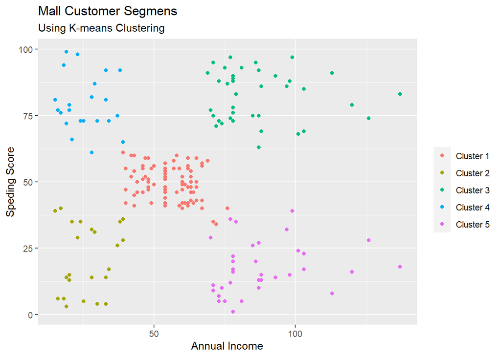

```r
set.seed(111)
ggplot(data = k_newdata, aes(x = Annual.Income..k.., y = Spending.Score..1.100.)) +
  geom_point(stat = "identity",
             aes(color = as.factor(customerClusters$cluster))) +
  scale_color_discrete(name = " ",
                       breaks = c("1", "2", "3", "4", "5"),
                       labels = c("Cluster 1", "Cluster 2", "Cluster 3", "Cluster 4", "Cluster 5")) +
  ggtitle("Mall Customer Segmens", subtitle = "Using K-means Clustering") +
  xlab("Annual Income") +
  ylab("Speding Score")
```

Cluster 1. Customers with medium annual income and medium annual spend

Cluster 2. Customers with low annual income and low annual spend

Cluster 3. Customers with high annual income and high annual spend

Cluster 4. Customers low annual income but high annual spend

Cluster 5. Customers with high annual income and low annual spend

# 2. Customer Segmentation with Age and Spending Score

```r
# select variables Age and Spending Score
k_newdata_Age_Spending <- Mall_Customers[ , c(3,5)]
```

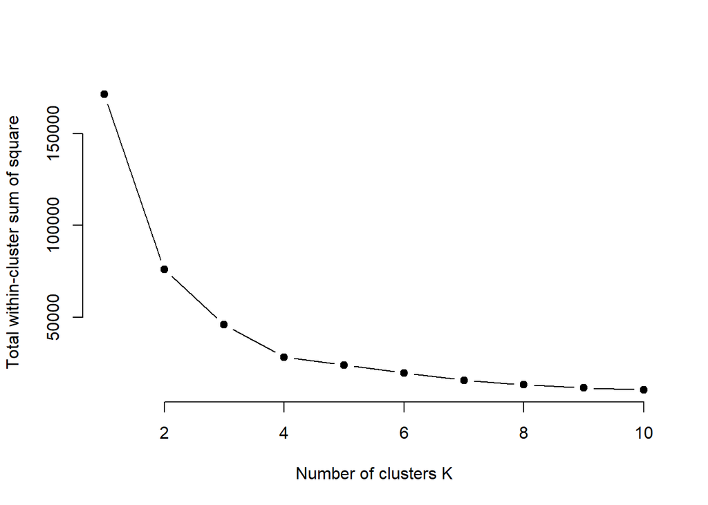

```r
library(purrr)
set.seed(1)
# function to calculate total within-cluster sum of square (WCSS)
wcss <- function(k) {
  kmeans(k_newdata_Age_Spending,
         k,
         iter.max = 100,
         nstart = 100,
         algorithm = "Lloyd" )$tot.withinss
}
# compute and plot wcss for k = 1 to k = 10
k_values <- 1:10

wcss_values <- map_dbl(k_values, wcss)

plot(k_values, wcss_values,
     type = "b",
     pch = 19,
     frame = FALSE,
     xlab = "Number of clusters K",
     ylab = "Total within-cluster sum of square")
```

# Compute k-means with k = 4

```r
set.seed(1)
customerClusters_Age_Spending <- kmeans(k_newdata_Age_Spending, 4)
customerClusters_Age_Spending
```

```
## K-means clustering with 4 clusters of sizes 48, 47, 48, 57
##
## Cluster means:
##        Age Spending.Score..1.100.
## 1 55.70833               48.22917
## 2 27.61702               49.14894
## 3 43.29167               15.02083
## 4 30.17544               82.35088
##
## Clustering vector:
##   [1] 2 4 3 4 2 4 3 4 3 4 3 4 3 4 3 4 2 2 3 4 2 4 3 4 3 4 3 2 3 4 3 4 3 4 3 4 3
##  [38] 4 3 4 1 4 1 2 3 2 1 2 2 2 1 2 2 1 1 1 1 1 2 1 1 2 1 1 1 2 1 1 2 2 1 1 1 1
##  [75] 1 2 1 2 2 1 1 2 1 1 2 1 1 2 2 1 1 2 1 2 2 2 1 2 1 2 2 1 1 2 1 2 1 1 1 1 1
## [112] 2 2 2 2 2 1 1 1 1 2 2 2 4 2 4 1 4 3 4 3 4 2 4 3 4 3 4 3 4 3 4 2 4 3 4 1 4
## [149] 3 4 3 4 3 4 3 4 3 4 3 4 1 4 3 4 3 4 3 4 3 2 3 4 3 4 3 4 3 4 3 4 3 4 3 4 2
## [186] 4 3 4 3 4 3 4 3 4 3 4 3 4 3 4
##
## Within cluster sum of squares by cluster:
## [1]  5694.396  6203.064 10102.896  6165.228
##  (between_SS / total_SS =  83.6 %)
##
## Available components:
##
## [1] "cluster"      "centers"      "totss"        "withinss"     "tot.withinss"
## [6] "betweenss"    "size"         "iter"         "ifault"
```

# Visualization K-means Cluster of Age and Speding Score

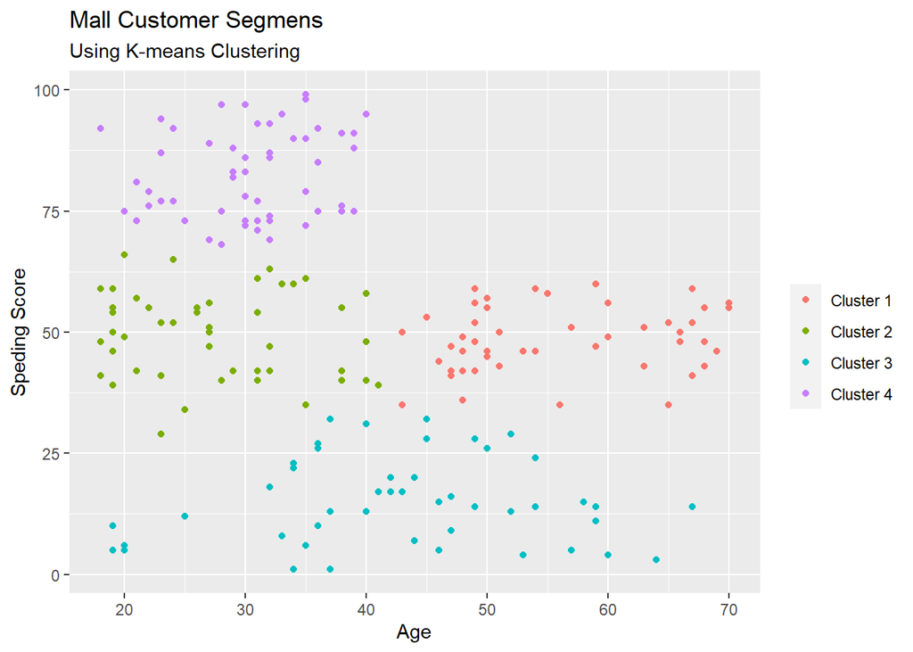

```r
set.seed(1)
ggplot(data = k_newdata_Age_Spending, aes(x = Age, y = Spending.Score..1.100.)) +
  geom_point(stat = "identity",
             aes(color = as.factor(customerClusters_Age_Spending$cluster))) +
  scale_color_discrete(name = " ",
                       breaks = c("1", "2", "3", "4"),
                       labels = c("Cluster 1", "Cluster 2", "Cluster 3", "Cluster 4")) +
  ggtitle("Mall Customer Segmens", subtitle = "Using K-means Clustering") +
  xlab("Age") +
  ylab("Speding Score")
```

Cluster 1. Customers with high age and medium annual spend

Cluster 2. Customers with low age and medium annual spend

Cluster 3. Customers with low to high of age and low annual spend

Cluster 4. Customers low age but high annual spend

# 3. Customer Segmentation with Age, Anual Income and Spending Score

```r
# select variables Age, Anual Income and Spending Score
k_newdata_Age_Income_Spending <- Mall_Customers[ , c(3:5)]
```

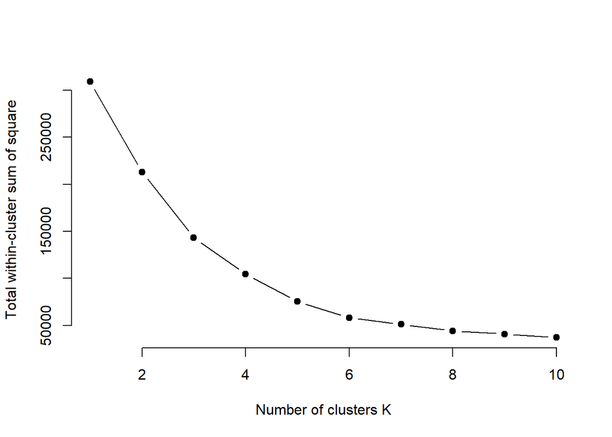

```r
library(purrr)
set.seed(1)
# function to calculate total within-cluster sum of square (WCSS)
wcss <- function(k) {
  kmeans(k_newdata_Age_Income_Spending,
         k,
         iter.max = 100,
         nstart = 100,
         algorithm = "Lloyd" )$tot.withinss
}
# compute and plot wcss for k = 1 to k = 10
k_values <- 1:10

wcss_values <- map_dbl(k_values, wcss)
plot(k_values, wcss_values,
     type = "b",
     pch = 19,
     frame = FALSE,
     xlab = "Number of clusters K",
     ylab = "Total within-cluster sum of square")
```

# Compute k-means with k = 6

```r
set.seed(1)
customerClusters_Age_Income_Spending <- kmeans(k_newdata_Age_Income_Spending, 6)
customerClusters_Age_Income_Spending
```

```
## K-means clustering with 6 clusters of sizes 45, 35, 21, 39, 38, 22
##
## Cluster means:
##        Age Annual.Income..k.. Spending.Score..1.100.
## 1 56.15556           53.37778               49.08889
## 2 41.68571           88.22857               17.28571
## 3 44.14286           25.14286               19.52381
## 4 32.69231           86.53846               82.12821
## 5 27.00000           56.65789               49.13158
## 6 25.27273           25.72727               79.36364
##
## Clustering vector:
##   [1] 3 6 3 6 3 6 3 6 3 6 3 6 3 6 3 6 3 6 3 6 3 6 3 6 3 6 3 6 3 6 3 6 3 6 3 6 3
##  [38] 6 3 6 1 6 1 5 3 6 1 5 5 5 1 5 5 1 1 1 1 1 5 1 1 5 1 1 1 5 1 1 5 5 1 1 1 1
##  [75] 1 5 1 5 5 1 1 5 1 1 5 1 1 5 5 1 1 5 1 5 5 5 1 5 1 5 5 1 1 5 1 5 1 1 1 1 1
## [112] 5 5 5 5 5 1 1 1 1 5 5 5 4 5 4 2 4 2 4 2 4 5 4 2 4 2 4 2 4 2 4 5 4 2 4 2 4
## [149] 2 4 2 4 2 4 2 4 2 4 2 4 2 4 2 4 2 4 2 4 2 4 2 4 2 4 2 4 2 4 2 4 2 4 2 4 2
## [186] 4 2 4 2 4 2 4 2 4 2 4 2 4 2 4
##
## Within cluster sum of squares by cluster:
## [1]  8062.133 16690.857  7732.381 13972.359  7742.895  4099.818
##  (between_SS / total_SS =  81.1 %)
##
## Available components:
##
## [1] "cluster"      "centers"      "totss"        "withinss"     "tot.withinss"
## [6] "betweenss"    "size"         "iter"         "ifault"
```

ref: “https://data-flair.training/blogs/r-data-science-project-customer-segmentation/” “https://www.youtube.com/watch?v=Whlis-6vsUY”

# Others fuctions or libraries

```r
# select variables that interested
k_newdata2 <- Mall_Customers[ , c(4:5)]
```

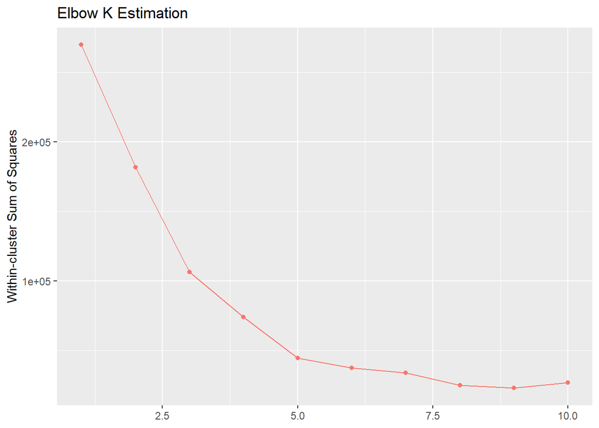

```r
# K estimation using Elbow approach
set.seed(111)
tot.withinss <- vector("numeric", length = 10)
for (i in 1:10) {
    kDet <- kmeans(k_newdata2, i)
    tot.withinss[i] <- kDet$tot.withinss
}

ggplot(as.data.frame(tot.withinss), aes(x = seq(1,10), y = tot.withinss)) +
    geom_point(col = "#F8766D") +
    geom_line(col = "#F8766D") +
    theme(axis.title.x.bottom = element_blank()) +
    ylab("Within-cluster Sum of Squares") +
    xlab("Number of Clusters") +
    ggtitle("Elbow K Estimation")
```

```r
library(factoextra)
```

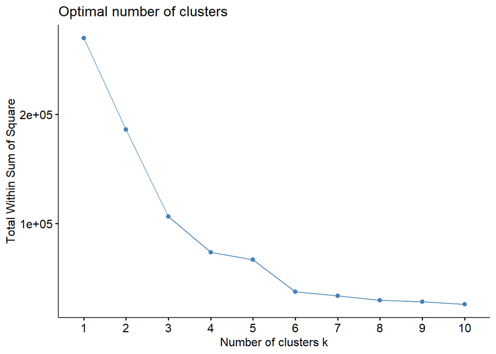

```r
fviz_nbclust(k_newdata2, kmeans, method = "wss")
```

```r
# Cluster
set.seed(111)
customerClusters2 <- kmeans(k_newdata, 5)
customerClusters2
```

```
## K-means clustering with 5 clusters of sizes 81, 23, 39, 22, 35
##
## Cluster means:
##   Annual.Income..k.. Spending.Score..1.100.
## 1           55.29630               49.51852
## 2           26.30435               20.91304
## 3           86.53846               82.12821
## 4           25.72727               79.36364
## 5           88.20000               17.11429
##
## Clustering vector:
##   [1] 2 4 2 4 2 4 2 4 2 4 2 4 2 4 2 4 2 4 2 4 2 4 2 4 2 4 2 4 2 4 2 4 2 4 2 4 2
##  [38] 4 2 4 2 4 2 1 2 4 1 1 1 1 1 1 1 1 1 1 1 1 1 1 1 1 1 1 1 1 1 1 1 1 1 1 1 1
##  [75] 1 1 1 1 1 1 1 1 1 1 1 1 1 1 1 1 1 1 1 1 1 1 1 1 1 1 1 1 1 1 1 1 1 1 1 1 1
## [112] 1 1 1 1 1 1 1 1 1 1 1 1 3 5 3 1 3 5 3 5 3 1 3 5 3 5 3 5 3 5 3 1 3 5 3 5 3
## [149] 5 3 5 3 5 3 5 3 5 3 5 3 5 3 5 3 5 3 5 3 5 3 5 3 5 3 5 3 5 3 5 3 5 3 5 3 5
## [186] 3 5 3 5 3 5 3 5 3 5 3 5 3 5 3
##
## Within cluster sum of squares by cluster:
## [1]  9875.111  5098.696 13444.051  3519.455 12511.143
##  (between_SS / total_SS =  83.5 %)
##
## Available components:
##
## [1] "cluster"      "centers"      "totss"        "withinss"     "tot.withinss"
## [6] "betweenss"    "size"         "iter"         "ifault"
```

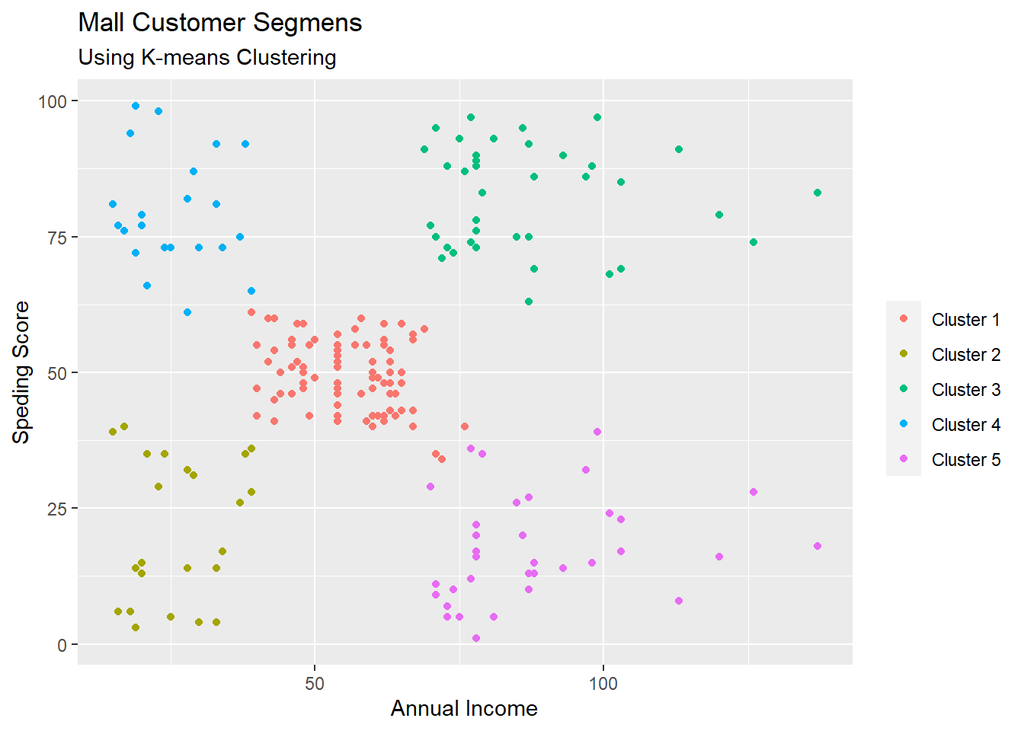

```r
# Visualization Cluster
set.seed(111)
ggplot(data = k_newdata2, aes(x = Annual.Income..k.., y = Spending.Score..1.100.)) +
  geom_point(stat = "identity",
             aes(color = as.factor(customerClusters2$cluster))) +
  scale_color_discrete(name = " ",
                       breaks = c("1", "2", "3", "4", "5"),
                       labels = c("Cluster 1", "Cluster 2", "Cluster 3", "Cluster 4", "Cluster 5")) +
  ggtitle("Mall Customer Segmens", subtitle = "Using K-means Clustering") +
  xlab("Annual Income") +
  ylab("Speding Score")
```

Cluster 1. Customers with medium annual income and medium annual spend

Cluster 2. Customers with low annual income and low annual spend

Cluster 3. Customers with high annual income and high annual spend

Cluster 4. Customers low annual income but high annual spend

Cluster 5. Customers with high annual income and low annual spend

ref: “https://www.kaggle.com/code/ioannismesionis/mall-customer-segmentation-unsupervised-learning/notebook”